## Tutorial for GitHub Issues

In this R Notebook presentation, we will give a brief introduction on how we can use [GitHub issues](https://guides.github.com/features/issues/) to organize a project.

This tutorial is adapted from Ian Bicking’s blog: [How We Use GitHub Issues To Organize a Project](http://www.ianbicking.org/blog/2014/03/use-github-issues-to-organize-a-project.html) and GitHub Guides: [Mastering Issues](https://guides.github.com/features/issues/).

### Issues

Issues are a great way to keep track of tasks, enhancements, and bugs for your projects.

They’re kind of like email—except they can be shared and discussed with the rest of your team.

Most software projects have a bug tracker of some kind. GitHub’s tracker is called **Issues**, and has its own section in every repository.

GitHub issues has a slim set of features:

- Issues, of course
- Issues can be assigned
- Issues belong to zero or one milestone
- Issues can have any number of tags

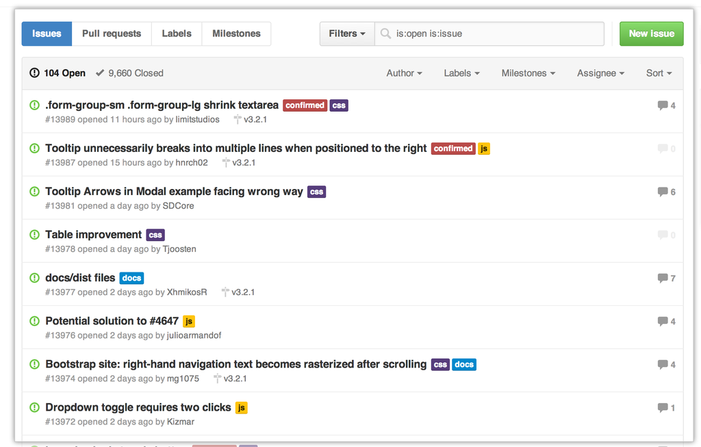

A typical issue on GitHub looks a bit like this:

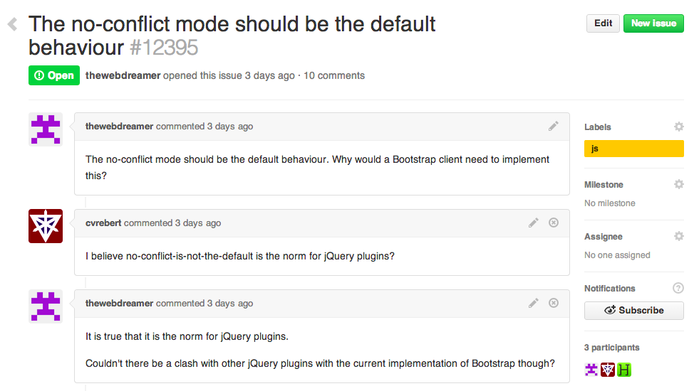

- A **title** and **description** describe what the issue is all about.
- Color-coded **labels** help you categorize and filter your issues (just like labels in email).
- A **milestone** acts like a container for issues. This is useful for associating issues with specific features or project phases
- One or more **assignees** are responsible for working on the issue at any given time.
- **Comments** allow anyone with access to the repository to provide feedback.

### Milestones

When we are working on a project, there are a couple of things we may want to track:

1. What we are doing right now?
2. What aren’t we doing right now?
3. What aren’t we sure about?

Then, it will be a good choice to use milestones.

Milestones are groups of issues that correspond to a project, feature, or time period. People use them in many different ways in software development.

For example, we can classify our issues into several milestones:

- **Stuff we are doing right now:** this is the “main” milestone. We give it a name and we write down what we are trying to accomplish with the milestone. We create a new milestone when we are ready for the next iteration.
- **Stuff we’ll probably do soon:** this is a standing “Next Tasks” milestone. We never change or rename this milestone.
- **Stuff we probably won’t do soon:** this is a standing “Blue Sky” milestone. We refer to these tickets and sometimes look through them, but they are easy to ignore, somewhat intentionally ignored.
- **What aren’t we sure about?:** issues with no milestone.

### Labels

Labels are a great way to organize different types of issues. Issues can have as many labels as you want, and you can filter by one or many labels at once.

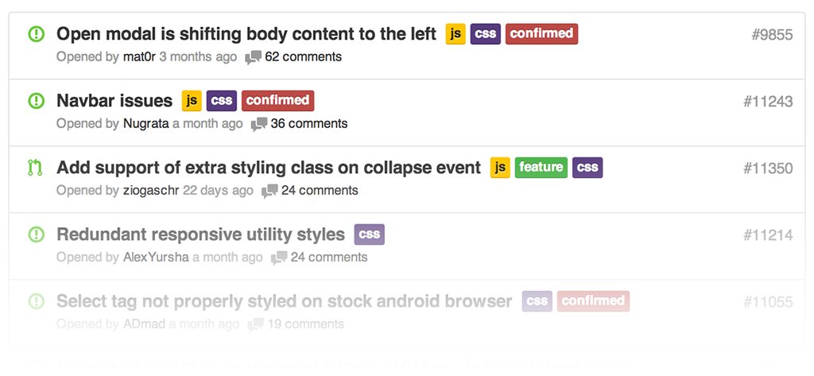

### Assignees

Each issue can have one or more assignees (up tp 10) — one person that’s responsible for moving the issue forward. Assignees are selected the same way milestones are, through the grey bar at the top of the issue.

### Notifications, @mentions and References

**Notifications** are GitHub’s way to keep up to date with your Issues. You can use them to find out about new issues on repositories, or just to know when someone needs your input to move forward on an issue.

There are two ways to receive notifications: via email, and via the web. You can configure how you receive notifications in your settings. If you plan on receiving a lot of notifications, we like to recommend that you receive web + email notifications for **Participating** and web notifications for **Watching**.

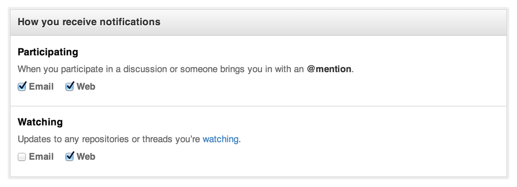

**Mentions** are the way that we reference other GitHub users inside of GitHub Issues. Inside of the description or any comment of the issue, include the @username of another GitHub user to send them a notification. This works very similar to how Twitter uses @mentions.

One of the more interesting ways to use GitHub Issues is to **reference** issues directly from commits. Include the issue number inside of the commit message.

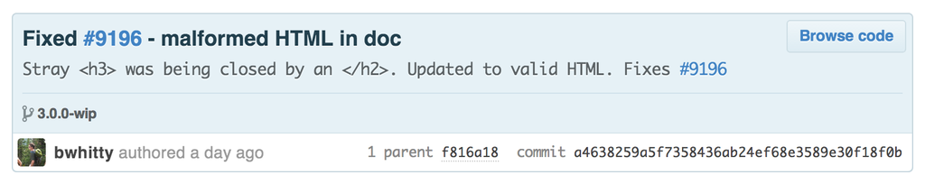

By prefacing your commits with “Fixes”, “Fixed”, “Fix”, “Closes”, “Closed”, or “Close” when the commit is merged into master, it will also automatically close the issue.

References make it possible to deeply connect the work being done with the bug being tracked, and are a great way to add visibility into the history of your project.

### References

1. GitHub Guides: Mastering Issues https://guides.github.com/features/issues/
2. Blog of Ian Bicking: How We Use GitHub Issues To Organiza a Project http://www.ianbicking.org/blog/2014/03/use-github-issues-to-organize-a-project.html